# Synaptome Statistics: Report 201705

2017-05-15

# 1 Synaptome Statistics: Notes

The following is a short report on the exploration of the Kristina15 (K15). Putative synapse locations have been detected in kristina15 with Forrest’s synapse detection algorithm. For each feature channel (Synapsin, VGlut, psd95, etc.) an 11x11x11 cube is extracted around each putative synapse location and the pixel intensities are summed, creating a feature vector of length (number of channels, say $d$). This gives us an $n \times d$ matrix, where the $n$ rows correspond to putative synapses and the $d$ columns correspond to the summed immunoflorescence in each channel.

We have run [MEDA](http://github.com/neurodata/meda/) on a sample of 5000 putative synapse locations in the Kristina15 dataset. The hierarchical clustering results are plotted below. For this particular run the data was [Z-scored](https://en.wikipedia.org/wiki/Standard_score#Calculation_from_raw_score)

## 1.1 Clustering

We have implemented our own Hierarchical Mclust function by augmenting Mclust. In the course of exploring we used the full suite of models available in [mclustModelNames p. 88](https://cran.r-project.org/web/packages/mclust/mclust.pdf)

After looking through the BIC plots of each of the 11 models for each node of the tree it seemed best to use the unconstrained model “VVV” = ellipsoidal, varying volume, shape, and orientation.

The first pass of BIC on K15 with 10,000 sample points, appear below and both show that “VVV” is the best model when comparing for K = {1,2}.

[K15](http://docs.neurodata.io/meda/examples/Kristina15/bic317_size10000/bicK15Raw_Node.pdf)

[figure not shown]

Towards the bottom of the tree, where clusters are getting smaller “VVV” tends to suggest against splitting the data. Looking through the BIC plots for multiple explorations we also see that “VVV” is not very bad when compared to the other models.  
These observations seem to justify our choice “VVV” for further use.

[K15](http://docs.neurodata.io/meda/examples/Kristina15/bic317_size10000/bicK15Raw_Node222.pdf)

[figure not shown]

## 1.2 Scaling

We have looked at various transformations of the data: Raw, $log_{10}$, and scaling between 0 and 1000 and Z-scoring. Full lab notebooks can be found [here](http://docs.neurodata.io/meda/)

When scaling, we transform each feature column individualy. For log_10 scaling we take the base 10 logarithm of the values in each column. If any of the values are 0 we first add 1 to the column and then take the logarithm.

When scaling between 0 and 1000, we replace each column, x, with the column defined by (x - min(x))/(max(x) - min(x)) * 1000

When Z-scoring, we subtract the column mean and divide by the column’s sample standard deviation.

Below are our stacked level mean plots which show for each level in the cluster tree (separated by black horizonal lines) the means accross each of the features (low - purple, high - orange).

- [K15 Raw](http://docs.neurodata.io/meda/examples/Kristina15/figs/k15Raw_seed1234_size10000.png)
- [K15 Log_10](http://docs.neurodata.io/meda/examples/Kristina15/figs/k15Log_seed1234_size10000.png)
- [K15 0-1000](http://docs.neurodata.io/meda/examples/Kristina15/figs/k1501e3_seed1234_size10000.png)
- [K15 Z-scored](http://docs.neurodata.io/meda/examples/Kristina15/figs/k15Zscored_seed1234_size10000.png)

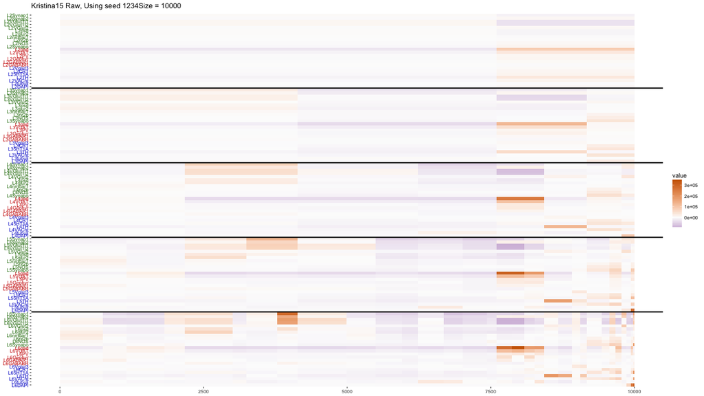

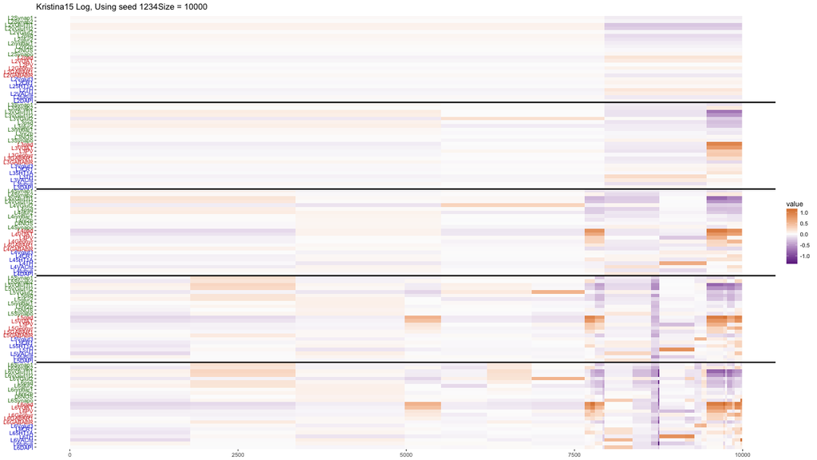

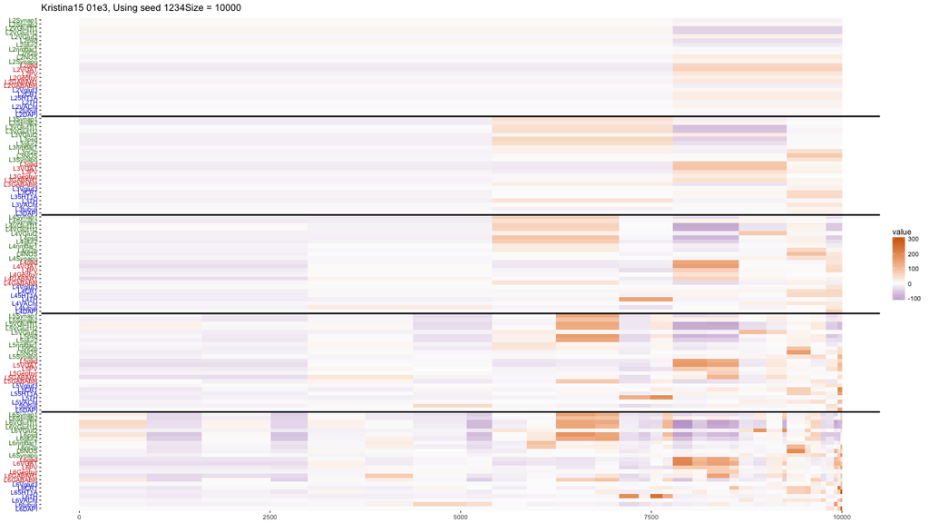

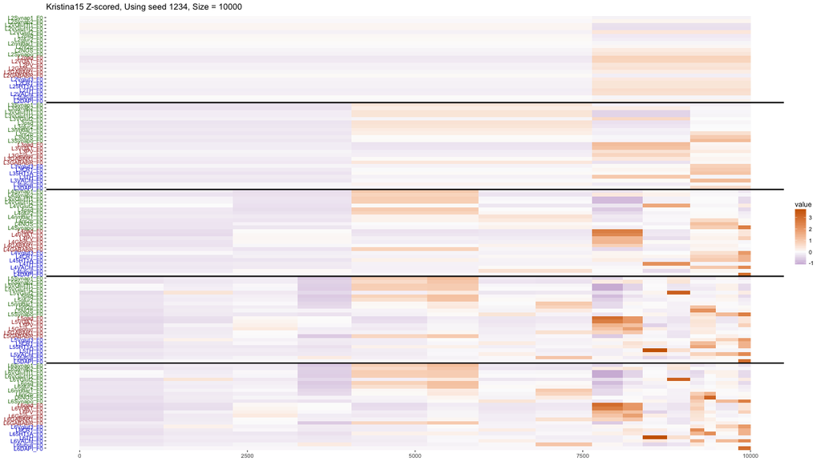

#### 1.2.0.1 Dendrogram

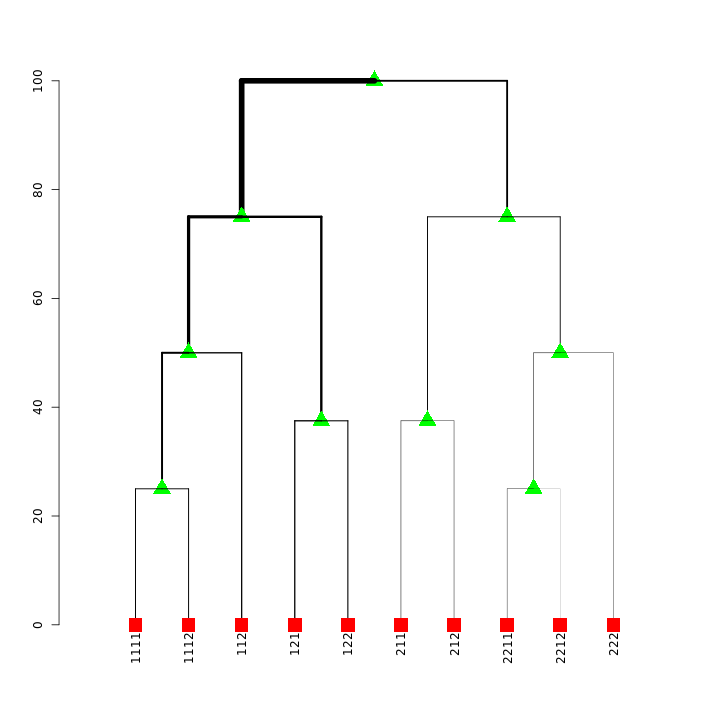

#### 1.2.0.2 Stacked Cluster Means plot

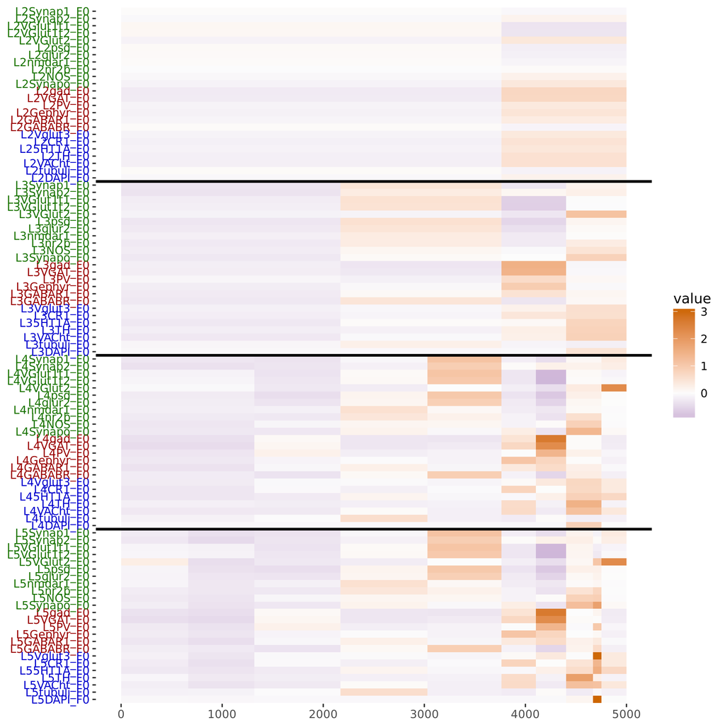

## 1.3 Synaptogram Code

We currently have code that generates synaptograms [here](https://github.com/neurodata/synaptome-stats/blob/17f0c715a365b910794852f5e3741e44aae102c8/Code2/R/k15Synaptograms.R). We are working to make sure that our generated synaptograms correspond to the correct locations in the image space and that the proper scaling transformations are being applied. We have decided that z-scoreing appears to be best and are employing that to all of our analyses.

#### 1.3.0.1 [Draft example synaptogram from the K15 dataset.](http://cis.jhu.edu/~jesse/fotd/20170509/synaptograms/k15syn_rscale_C122_769_7958_26.png)

[figure not shown]